# Question 1

## 1a

```r
# The logic in this script is to generate training data once, and generate one prediction for each value of k
library(FNN)
library(tidyverse)
set.seed(43251)
n = 400  # sample size for each simulation
p = 3 # number of predictors
k_values = seq(1, 29, 2)  # the k values to try
x0 = matrix(c(0.5, 0.7, 1), nrow = 1)  # test point
# true value at test point (using the true data generating process)
f0 = 0.5*x0[1, 1] + sin(x0[1, 2]) - 0.3*x0[1, 3]^2

# generate training data
X = matrix(rnorm(n*p), nrow = n, ncol = p)
y = 0.5*X[, 1] + sin(X[, 2]) - 0.3*X[, 3]^2 + rnorm(n, sd = 0.1)
pred = numeric(length(k_values))
for (m in seq_along(k_values)) {
    k = k_values[m]
    knn.fit = knn.reg(train = X, test = x0, y = y,
                        k = k, algorithm = "brute")
    pred[m] = knn.fit$pred
}
res <- data.frame(k = k_values, prediction = pred, truth = f0)
res
```

```
    k prediction     truth
1   1  0.7888302 0.5942177
2   3  0.6621674 0.5942177
3   5  0.6642853 0.5942177
4   7  0.6100117 0.5942177
5   9  0.6318671 0.5942177
6  11  0.4925114 0.5942177
7  13  0.5222989 0.5942177
8  15  0.5810203 0.5942177
9  17  0.5738171 0.5942177
10 19  0.5751479 0.5942177
11 21  0.5800517 0.5942177
12 23  0.5519177 0.5942177
13 25  0.5214556 0.5942177
14 27  0.4952957 0.5942177
15 29  0.4972667 0.5942177
```

## 1b

```r
# Define function
Generate_and_KNN_reg <- function() {
  X = matrix(rnorm(n*p), nrow = n, ncol = p)
  y = 0.5*X[, 1] + sin(X[, 2]) - 0.3*X[, 3]^2 + rnorm(n, sd = 0.1)
  pred = numeric(length(k_values))
  for (m in seq_along(k_values)) {
    k = k_values[m]
    knn.fit = knn.reg(train = X, test = x0, y = y,
                      k = k, algorithm = "brute")
    pred[m] = knn.fit$pred
  }
  return(pred)
}

rep <- 200
q1b_res <- matrix(NA, nrow = rep, ncol = length(k_values))

for (r in 1:rep) {
    q1b_res[r, ] <- Generate_and_KNN_reg()
}

bias <- colMeans(q1b_res) - f0
variance <- colMeans(sweep(q1b_res, 2, colMeans(q1b_res), "-")^2)
mean_squared_error <- colMeans((q1b_res - f0)^2)
validation <- abs(bias^2 + variance - mean_squared_error) < 1e-15
q1b_report <- data.frame(k = k_values, bias = bias,
                         variance = variance, mse = mean_squared_error,
                         validation = validation)
q1b_report
```

```
    k         bias    variance        mse validation
1   1 -0.001248923 0.037181204 0.03718276       TRUE
2   3 -0.029361680 0.019831580 0.02069369       TRUE
3   5 -0.040815728 0.014731018 0.01639694       TRUE
4   7 -0.045589732 0.010865566 0.01294399       TRUE
5   9 -0.051867114 0.009467440 0.01215764       TRUE
6  11 -0.062360901 0.009506180 0.01339506       TRUE
7  13 -0.067797856 0.009397702 0.01399425       TRUE
8  15 -0.070662763 0.008542311 0.01353554       TRUE
9  17 -0.081499864 0.008213727 0.01485595       TRUE
10 19 -0.089385641 0.008429774 0.01641957       TRUE
11 21 -0.096080776 0.008413451 0.01764497       TRUE
12 23 -0.102803643 0.008103017 0.01867161       TRUE
13 25 -0.107847900 0.008091147 0.01972232       TRUE
14 27 -0.114428351 0.007777947 0.02087180       TRUE
15 29 -0.121688194 0.007474576 0.02228259       TRUE
```

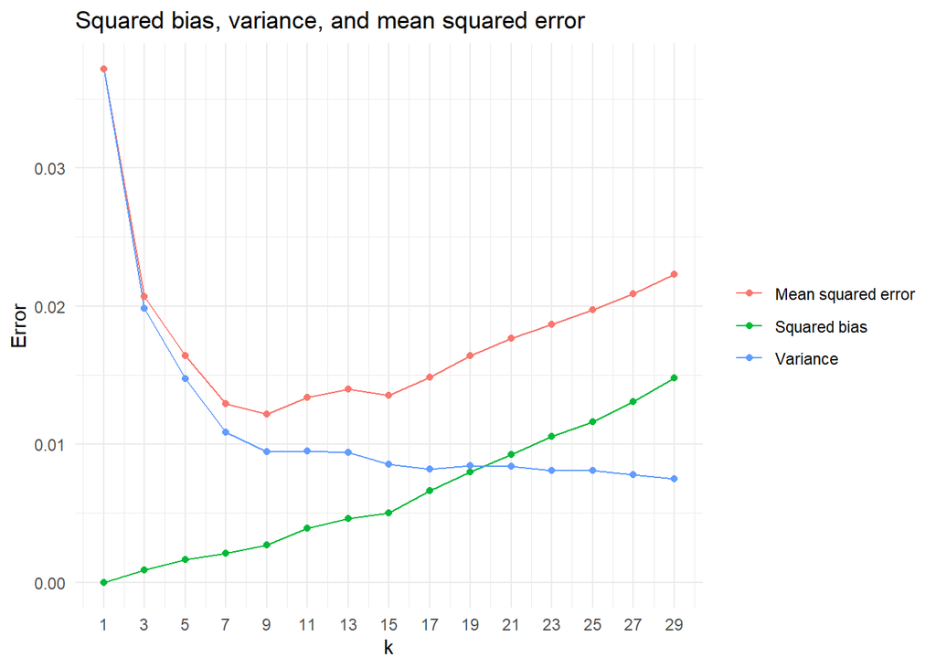

```r
q1b_report |>
  transmute(k, `Squared bias` = bias^2, Variance = variance,
            `Mean squared error` = mse) |>
  pivot_longer(-k, names_to = "Metric", values_to = "Value") |>
  ggplot(aes(x = k, y = Value, color = Metric)) +
  geom_line() +
  geom_point() +
  scale_x_continuous(breaks = k_values) +
  labs(x = "k", y = "Error", color = NULL,
       title = "Squared bias, variance, and mean squared error") +
  theme_minimal()
```

For each fixed $k$, let $\hat{f}_i$ be the prediction from simulation $i$ and $f$ be the true value at the test point. The following equations proves that the sum of the squared bias and variance equals the mean squared error. For this question, the irreducible error is absent because we use the true mean in the calculation of mean squared error and squared bias in each iteration.

$$\begin{aligned}
\text{Mean squared error}
&= \frac{1}{200}\sum_{i=1}^{200}(\hat{f}_i-f)^2 \\
&= \frac{1}{200}\sum_{i=1}^{200}(\hat{f}_i^2-2f\hat{f}_i+f^2) \\
&= \overline{\hat{f}^{2}}-2f\overline{\hat{f}}+f^2.
\end{aligned}$$

$$\begin{aligned}
\text{Squared bias}
&= (\overline{\hat{f}}-f)^2 \\
&= (\overline{\hat{f}})^2-2f\overline{\hat{f}}+f^2.
\end{aligned}$$

$$\begin{aligned}
\text{Variance}
&= \frac{1}{200}\sum_{i=1}^{200}(\hat{f}_i-\overline{\hat{f}})^2 \\
&= \overline{\hat{f}^{2}}-(\overline{\hat{f}})^2.
\end{aligned}$$

where

$$\overline{\hat{f}^{2}}=\frac{1}{200}\sum_{i=1}^{200}\hat{f}_i^2
\qquad\text{and}\qquad
\overline{\hat{f}}=\frac{1}{200}\sum_{i=1}^{200}\hat{f}_i.$$

The bias-variance tradeoff in this knn example is similar to what we’ll get in ridge and lasso regression. In ridge regression, the bias-variance tradeoff is controlled by the regularization parameter $\lambda$. As $\lambda$ increases, the model becomes more regularized, leading to a decrease in variance but an increase in bias. The optimal value of $\lambda$ balances this tradeoff to minimize the mean squared error.

# Question 2

## 2a

```r
library(FNN)
library(glmnet)
set.seed(43252)

n <- 400 # Number of training observations
p <- 30 # Number of features (not all true)
lambda <- 10^seq(0, -4, length.out = 41) # Regularization parameter values
results <- data.frame(
  Setting = c("Independent", "Correlated"),
  KNN_MSE = NA_real_, Lasso_MSE = NA_real_,
  Lambda = NA_real_, Nonzero = NA_integer_
)

for (l in 1:2) {
  Sigma <- diag(p)
  if (l == 2) Sigma <- 0.8 + 0.2 * diag(p)
  # Sigma2 = 0.8 at off-diag and 1 at diag

  X <- matrix(rnorm((n + 1000) * p), ncol = p) %*% chol(Sigma)
  y <- 0.5 * X[, 1] + sin(X[, 2]) - 0.3 * X[, 3]^2 +
    rnorm(n + 1000, sd = 0.1)
  test.X <- X[(n + 1):(n + 1000), ]
  test.y <- y[(n + 1):(n + 1000)]
  X <- X[1:n, ]
  y <- y[1:n]

  knn.fit <- knn.reg(X, test.X, y, k = 5, algorithm = "brute")
  results$KNN_MSE[l] <- mean((test.y - knn.fit$pred)^2)

  # Estimate means and scales separately in each training fold.
  fold <- sample(rep(1:10, each = n / 10))
  cv.mse <- matrix(NA_real_, nrow = 10, ncol = length(lambda))
  for (m in 1:10) {
    # standardizing training X
    X.mean <- colMeans(X[fold != m, ])
    X.fit <- sweep(X[fold != m, ], 2, X.mean, "-")
    X.sd <- sqrt(colMeans(X.fit^2))
    X.fit <- sweep(X.fit, 2, X.sd, "/")
    # standardizing validation X
    X.valid <- sweep(X[fold == m, ], 2, X.mean, "-")
    X.valid <- sweep(X.valid, 2, X.sd, "/")
    # get the mean of the training y but deduction is done below
    y.mean <- mean(y[fold != m])

    # This finds the beta that minimize the loss for each lambda
    lasso.fit <- glmnet(
      X.fit, y[fold != m] - y.mean, alpha = 1, lambda = lambda,
      intercept = FALSE, standardize = FALSE
    )
    # This returns the predicted values and MSE for the validation set.
    y.hat <- predict(lasso.fit, newx = X.valid, s = lambda) + y.mean
    cv.mse[m, ] <- colMeans((y[fold == m] - y.hat)^2)
  }
  # Choose the optimal lambda based on cross-validation
  lambda.min <- lambda[which.min(colMeans(cv.mse))]

  # Refit model with optimal lambda with all training observations.
  X.mean <- colMeans(X)
  X.fit <- sweep(X, 2, X.mean, "-")
  X.sd <- sqrt(colMeans(X.fit^2))
  X.fit <- sweep(X.fit, 2, X.sd, "/")

  # Notice that we standardize test data with mean and sd of training data
  test.X.fit <- sweep(test.X, 2, X.mean, "-")
  test.X.fit <- sweep(test.X.fit, 2, X.sd, "/")
  y.mean <- mean(y)
  lasso.fit <- glmnet(
    X.fit, y - y.mean, alpha = 1, lambda = lambda,
    intercept = FALSE, standardize = FALSE
  )
  test.pred <- as.vector(
    predict(lasso.fit, newx = test.X.fit, s = lambda.min)
  ) + y.mean

  results$Lasso_MSE[l] <- mean((test.y - test.pred)^2)
  results$Lambda[l] <- lambda.min
  results$Nonzero[l] <- sum(coef(lasso.fit, s = lambda.min)[-1, 1] != 0)
}

results
```

```
      Setting   KNN_MSE Lasso_MSE     Lambda Nonzero
1 Independent 0.5564800 0.2601745 0.02511886      11
2  Correlated 0.1608514 0.2259450 0.01000000      16
```

## 2b

The correlation seems to help KNN’s performance. When the covariates are independent, the data points are more spread out, making it harder for KNN to find similar neighbors. In the correlated setting, the data points are more clustered, which improves KNN’s ability to make accurate predictions.

Another reason why KNN performs better in the correlated setting is that the correlation structure makes it easier for the algorithm to identify similar observations. For example, if X1 is in true data generating process, but X2 is not. In cases where the features are independent, the prediction at (X1_0, X2_0) may not use a point with X1 close to X1_0 because its X2 value is not close to X2_0. In other words, the X2 feature disturbs the algorithm’s ability to find similar neighbors. However, in correlated settings, the correlation between the two features means that when X2 is close to X2_0, X1 is also likely to be close to X1_0, making the neighbor search to be more “precise”.

Lasso does not use all covariates because it performs variable selection by shrinking some coefficients to zero, effectively choosing a subset of the available features for the model.

## 2c

Lasso can only form linear combinations of the features that are included in the model. Therefore, unless we include squared or sine terms of the features, Lasso cannot capture nonlinear relationships in the data. KNN however, does not assume a linear relationship. Thus, it is more flexible and can capture more complex patterns in the data. This single test cannot fully represent the performance of both models across different scenarios.

# Question 3

## 3a

```r
library(FNN)
set.seed(43254)
p = 100
m_values = c(3, 30)
k_values = seq(2, 82, 8) # K nearest neighbors
test_mse = matrix(NA, nrow = length(k_values), ncol = 2)

# Each Xi is the 100 observed covariates/features/predictors for an observation
# We assume that each X's are generated from m covariates.
# Z is 400*m. 400 cases and their correspoding m latent variables
# A is the coefficient matrix for the linear combination (fixed for all cases)
# Z %*% t(A) we create the true (unobservable) covariates for all 400 cases
# + eta (only implicitly shown here) we get the observed covariates
# Each observed predictors Xi is linear combo of all latent var Zij
# Y is actually generated by only the first two latent variables
for (m in m_values) {
  A = matrix(runif(p*m, -2, 2), nrow = p, ncol = m)
  Z = matrix(rnorm(400*m), nrow = 400, ncol = m)
  X = Z %*% t(A) + matrix(rnorm(400*p), nrow = 400, ncol = p)
  y = Z[, 1] + Z[, 2] + rnorm(400)
  for (k in k_values) {
    knn.fit = knn.reg(train = X[1:200, ], test = X[201:400, ],
                      y = y[1:200], k = k, algorithm = "brute")
    test_mse[match(k, k_values), match(m, m_values)] =
      mean((y[201:400] - knn.fit$pred)^2)
  }
}
q3a_res <- data.frame(k = k_values, m3 = test_mse[, 1], m30 = test_mse[, 2])
q3a_res
```

```
    k       m3      m30
1   2 1.449265 3.457456
2  10 1.253345 2.583372
3  18 1.292923 2.533071
4  26 1.379955 2.524038
5  34 1.448416 2.512187
6  42 1.505892 2.560783
7  50 1.590057 2.562911
8  58 1.660186 2.593970
9  66 1.739597 2.607162
10 74 1.816963 2.651181
11 82 1.871802 2.672724
```

## 3b

```r
nsim = 50
test_mse = array(NA, dim = c(nsim, length(k_values), 2))
for (l in 1:nsim) {
  for (m in m_values) {
    A = matrix(runif(p*m, -2, 2), nrow = p, ncol = m)
    Z = matrix(rnorm(400*m), nrow = 400, ncol = m)
    X = Z %*% t(A) + matrix(rnorm(400*p), nrow = 400, ncol = p)
    y = Z[, 1] + Z[, 2] + rnorm(400)
    for (k in k_values) {
      knn.fit = knn.reg(train = X[1:200, ], test = X[201:400, ],
                        y = y[1:200], k = k, algorithm = "brute")
      test_mse[l, match(k, k_values), match(m, m_values)] =
        mean((y[201:400] - knn.fit$pred)^2)
    }
  }
}

mean_mse = apply(test_mse, c(2, 3), mean)
q3b_res <- data.frame(k = k_values, m3 = mean_mse[, 1], m30 = mean_mse[, 2])
q3b_res
```

```
    k       m3      m30
1   2 1.634822 3.062662
2  10 1.288062 2.349524
3  18 1.321139 2.345840
4  26 1.372628 2.378219
5  34 1.437850 2.412709
6  42 1.496497 2.455664
7  50 1.554715 2.492101
8  58 1.615062 2.527212
9  66 1.673644 2.556039
10 74 1.736733 2.589309
11 82 1.800274 2.618853
```

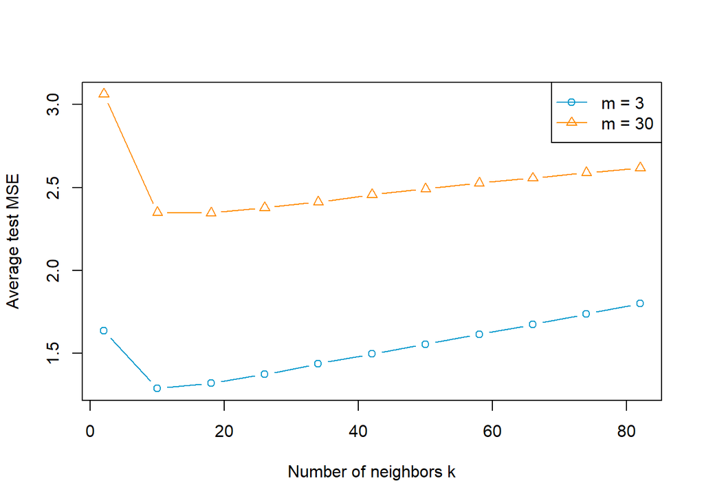

```r
matplot(k_values, mean_mse, type = "b", pch = c(1, 2), lty = 1,
        col = c("deepskyblue3", "darkorange"),
        xlab = "Number of neighbors k", ylab = "Average test MSE")
legend("topright", c("m = 3", "m = 30"),
       col = c("deepskyblue3", "darkorange"), lty = 1, pch = c(1, 2))
```

## 3c

When m = 3, the KNN model has a lower test MSE than when m = 30. When m = 3, X is only a linear combo of 3 latent variables, among which the first two are used to generate y. This suggests that X are comprised of mostly relevant information for predicting y, while the additional latent variables in the m = 30 case, the other 28 irrelevant latent variables stuffed into the generation of X, introduce noise that degrades the model’s performance.

Eta plays the role of random noise in the generation of the observed covariates X. Or it can also be viewed as the measurement error in the observed variables.

# Question 4

## 4a

```r
library(ElemStatLearn)

euclidean_distance <- function(x0, X) {
  sqrt(rowSums(sweep(X, 2, x0, "-")^2))
}

manhattan_distance <- function(x0, X) {
  rowSums(abs(sweep(X, 2, x0, "-")))
}

X <- zip.train[1:1000, -1]
y <- zip.train[1:1000, 1]
X_test <- zip.test[1:500, -1]
y_test <- zip.test[1:500, 1]

# X and y are training data. X_test are new positions to classify
# distance is a function either euclidean_distance or manhattan_distance
knn_classify <- function(X, y, X_test, distance) {
  y_hat <- integer(nrow(X_test))
  # Calculate distance between each test point and all training points
  # neighbor = a list of indices of the 5 nearest training points
  for (i in seq_len(nrow(X_test))) {
    d <- distance(X_test[i, ], X)
    neighbors <- order(d, seq_len(nrow(X)))[1:5]
    y_hat[i] <- which.max(tabulate(y[neighbors] + 1, nbins = 10)) - 1
  }
  y_hat
}

y_hat <- cbind(Euclidean = knn_classify(X, y, X_test, euclidean_distance),
               Manhattan = knn_classify(X, y, X_test, manhattan_distance))
```

## 4b

```r
for (l in 1:2) {
  cat(colnames(y_hat)[l], "test error:", mean(y_hat[, l] != y_test), "\n")
  print(table(Predicted = factor(y_hat[, l], levels = 0:9),
              True = factor(y_test, levels = 0:9)))
}
```

```
Euclidean test error: 0.122
         True
Predicted   0   1   2   3   4   5   6   7   8   9
        0 118   0   7   1   0   4   2   0   2   0
        1   0  66   0   0   2   0   0   0   0   1
        2   0   0  39   1   0   0   2   0   0   1
        3   0   0   0  23   0   4   0   0   2   0
        4   0   0   1   0  27   1   1   1   0   1
        5   0   0   0   1   0  13   0   0   0   0
        6   0   2   0   0   0   1  41   0   2   0
        7   0   0   0   0   1   1   0  34   0   4
        8   0   0   3   2   0   2   0   0  37   0
        9   1   0   0   1   4   0   0   1   1  41
Manhattan test error: 0.138
         True
Predicted   0   1   2   3   4   5   6   7   8   9
        0 118   0   6   1   0   5   3   0   4   0
        1   0  67   2   0   2   0   1   0   0   1
        2   0   0  35   0   0   0   2   0   0   0
        3   0   0   1  24   0   4   0   0   2   0
        4   0   0   1   1  27   1   0   1   0   1
        5   0   0   0   1   0  11   0   0   0   0
        6   0   1   0   0   0   2  40   0   2   0
        7   0   0   2   1   1   0   0  34   0   5
        8   0   0   2   0   0   3   0   0  34   0
        9   1   0   1   1   4   0   0   1   2  41
```

```r
cat(colnames(y_hat)[1], "test error:", mean(y_hat[, 1] != y_test), "\n")
```

```
Euclidean test error: 0.122
```

Number 2 is easily recognized as 0 or 8. Number 5 is often confused with 0 or 3. Number 9 is often mixed up with 7.

## 4c

```
[1] "digit  6  taken"
```

```
[1] "digit  2  taken"
```

```
[1] "digit  4  taken"
```

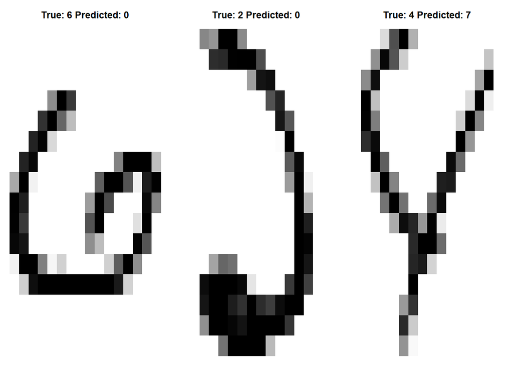

```r
# The first column for y_hat is for Euclidean distances
incorrect <- which(y_hat[, 1] != y_test)[1:3]
old_par <- par(mfrow = c(1, 3), mar = c(1, 1, 3, 1))
for (i in incorrect) {
  image(zip2image(zip.test, i), col = gray(256:0/256), zlim = c(0, 1),
        xlab = "", ylab = "", axes = FALSE,
        main = paste("True:", y_test[i], "Predicted:", y_hat[i, 1]))
}
```

```r
for (i in incorrect) {
  print(paste("True:", y_test[i], "Predicted:", y_hat[i, 1]))
}
```

```
[1] "True: 6 Predicted: 0"
[1] "True: 2 Predicted: 0"
[1] "True: 4 Predicted: 7"
```

```r
par(old_par)

cat("Different predictions:", sum(y_hat[, 1] != y_hat[, 2]), "\n")
```

```
Different predictions: 22
```

```r
table(Euclidean_correct = y_hat[, 1] == y_test,
      Manhattan_correct = y_hat[, 2] == y_test)
```

```
                 Manhattan_correct
Euclidean_correct FALSE TRUE
            FALSE    58    3
            TRUE     11  428
```

These numbers are written fairly messy, causing some confusion in classification. The two distances can have similar error while making mistakes on difficult cases. However, in this example, the two distances are either both correct or both incorrect for the vast majority of the test points.

# Question 5

The plot below uses the results from Question 1b with updated formatting. Run Question 1a and 1b first if running this chunk on its own.

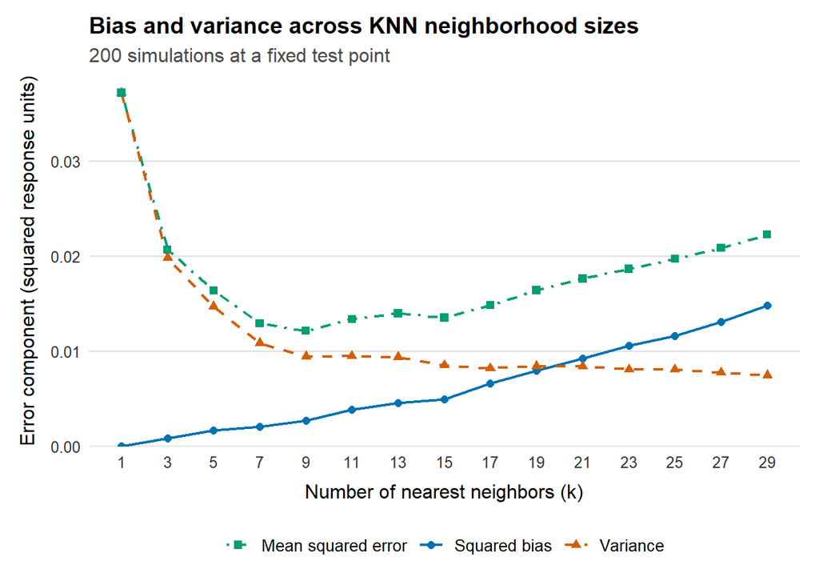

```r
q1b_report |>
  transmute(k, `Squared bias` = bias^2, Variance = variance,
            `Mean squared error` = mse) |>
  pivot_longer(-k, names_to = "Metric", values_to = "Value") |>
  ggplot(aes(x = k, y = Value, color = Metric,
             shape = Metric, linetype = Metric)) +
  geom_line(linewidth = 0.8) +
  geom_point(size = 2) +
  scale_color_manual(values = c(
    "Squared bias" = "#0072B2",
    "Variance" = "#D55E00",
    "Mean squared error" = "#009E73"
  )) +
  scale_shape_manual(values = c(
    "Squared bias" = 16, "Variance" = 17, "Mean squared error" = 15
  )) +
  scale_linetype_manual(values = c(
    "Squared bias" = "solid", "Variance" = "dashed",
    "Mean squared error" = "dotdash"
  )) +
  # Later questions redefine k_values; use the saved Question 1 results.
  scale_x_continuous(breaks = q1b_report$k) +
  scale_y_continuous(expand = expansion(mult = c(0, 0.05))) +
  expand_limits(y = 0) +
  labs(
    title = "Bias and variance across KNN neighborhood sizes",
    subtitle = paste(nrow(q1b_res), "simulations at a fixed test point"),
    x = "Number of nearest neighbors (k)",
    y = "Error component (squared response units)",
    color = NULL, shape = NULL, linetype = NULL
  ) +
  theme_minimal(base_size = 12) +
  theme(
    plot.title = element_text(size = 14, face = "bold"),
    plot.subtitle = element_text(color = "grey30"),
    plot.margin = margin(10, 12, 10, 12, unit = "pt"),
    plot.background = element_rect(fill = "white", color = NA),
    panel.grid.minor = element_blank(),
    panel.grid.major.x = element_blank(),
    panel.grid.major.y = element_line(color = "grey90"),
    axis.text = element_text(color = "grey20"),
    axis.title.x = element_text(margin = margin(t = 8)),
    axis.title.y = element_text(margin = margin(r = 8)),
    legend.position = "bottom",
    legend.text = element_text(size = 10)
  )
```

## 5b

Generally, I think the skill makes my plot clearer. More importantly, it is a lot more customizable.

name: stat432-plots description: Format plots produced in R for STAT 432 with consistent margins, titles, axes, labels, colors, and sizes. Use only when the user explicitly requests stat432-plots or asks to apply this skill; do not activate for general R or homework requests. —

# STAT 432 Plot Formatting

Apply readable, consistent formatting to the requested R plots, using the existing plotting system (base R or ggplot2). These are personal formatting defaults, not official course requirements. Follow explicit assignment or user requirements when they differ.

## Invocation and scope

- Require an explicit request such as `Use $stat432-plots to format this plot.` A mention of STAT 432, R, or plotting alone does not invoke this skill.
- Apply changes only to the plots requested. Preserve the underlying data, calculations, statistical meaning, and chosen plot type unless the user requests changes.

## Formatting rules

1. **Margins:** Leave enough room for tick labels, axis titles, and legends without clipping. Start with `par(mar = c(4.5, 4.5, 3, 1))` in base R (bottom, left, top, right; text lines), or `theme(plot.margin = margin(10, 12, 10, 12, unit = "pt"))` in ggplot2 (top, right, bottom, left). Increase the relevant margin for long labels. Restore any base R `par()` changes after drawing, preferably with `on.exit(par(old_par))` inside a plotting function.
2. **Titles:** Use a short, descriptive sentence-case title that names the comparison or relationship. Put simulation settings or other necessary context in a subtitle or caption. Avoid titles that assert unsupported conclusions.
3. **Axes:** Use meaningful limits and readable tick spacing. Start quantitative bar-chart axes at zero; for other plot types choose limits that reveal the data without hiding relevant observations. Use common scales for directly comparable panels. Clearly indicate logarithmic or other transformed scales and keep tick text horizontal when practical.
4. **Labels:** Give each axis a descriptive variable name and units where applicable. Replace raw code names with readable text. Name legend variables and groups clearly, and use consistent terminology and numeric precision across related plots. Include a legend when colors, shapes, or line types encode groups.
5. **Colors:** Use a white background, dark text, and restrained grid lines. Prefer `#0072B2` for a single series; for groups, start with `#0072B2`, `#D55E00`, `#009E73`, and `#CC79A7`. Keep group-to-color mappings consistent across plots, and supplement colors with shapes or line types where useful. For ordered or continuous values, use a perceptually ordered palette such as viridis. Avoid relying on red versus green alone.
6. **Sizes:** Start with a 7 by 4.5 inch figure. In Quarto use `fig-width: 7` and `fig-height: 4.5`; for raster export use 300 dpi. Start ggplot2 text at 12 pt, titles at 14 pt, points at size 2, and lines at `linewidth = 0.8`. In base R start with a 12 pt device font, `cex.main = 1.15`, `cex.lab = 1`, `cex.axis = 0.9`, `cex = 0.8`, and `lwd = 2`. These systems use different size units; adjust visually rather than treating their numeric settings as interchangeable. Enlarge multi-panel figures to keep text readable at the final display size.

## Visual check

Render the affected plots when R and the required dependencies are available. Inspect them at the intended output size for clipped text, overlapping labels, legible legends, distinguishable series, and consistent scales. Adjust spacing and dimensions as needed. If rendering is unavailable, state that the formatting was reviewed in code only.